# Easystats Performance

by Edneide Ramalho

15 Julho, 2021

This script is based on the video:

https://www.youtube.com/watch?v=Bi8sHIo3s1Y

from the Business Science YouTube Chanel

# 1 Libraries

```r
# install.packages("performance", dependences = TRUE)
```

```r
library(tidyverse)
library(performance)
```

# 2 Data

```r
glimpse(mpg)
```

```
## Rows: 234
## Columns: 11
## $ manufacturer <chr> "audi", "audi", "audi", "audi", "audi", "audi", "audi", "…
## $ model        <chr> "a4", "a4", "a4", "a4", "a4", "a4", "a4", "a4 quattro", "…
## $ displ        <dbl> 1.8, 1.8, 2.0, 2.0, 2.8, 2.8, 3.1, 1.8, 1.8, 2.0, 2.0, 2.…
## $ year         <int> 1999, 1999, 2008, 2008, 1999, 1999, 2008, 1999, 1999, 200…
## $ cyl          <int> 4, 4, 4, 4, 6, 6, 6, 4, 4, 4, 4, 6, 6, 6, 6, 6, 6, 8, 8, …
## $ trans        <chr> "auto(l5)", "manual(m5)", "manual(m6)", "auto(av)", "auto…
## $ drv          <chr> "f", "f", "f", "f", "f", "f", "f", "4", "4", "4", "4", "4…
## $ cty          <int> 18, 21, 20, 21, 16, 18, 18, 18, 16, 20, 19, 15, 17, 17, 1…
## $ hwy          <int> 29, 29, 31, 30, 26, 26, 27, 26, 25, 28, 27, 25, 25, 25, 2…
## $ fl           <chr> "p", "p", "p", "p", "p", "p", "p", "p", "p", "p", "p", "p…
## $ class        <chr> "compact", "compact", "compact", "compact", "compact", "c…
```

We are going to perform a linear regression and check the model performance.

# 3 Performance

```r
model_lm <- lm(hwy ~ displ + class, data = mpg)

model_lm
```

```
##
## Call:
## lm(formula = hwy ~ displ + class, data = mpg)
##
## Coefficients:
##     (Intercept)            displ     classcompact     classmidsize
##          38.953           -2.298           -5.312           -4.947
##    classminivan      classpickup  classsubcompact         classsuv
##          -8.799          -11.923           -4.699          -10.585
```

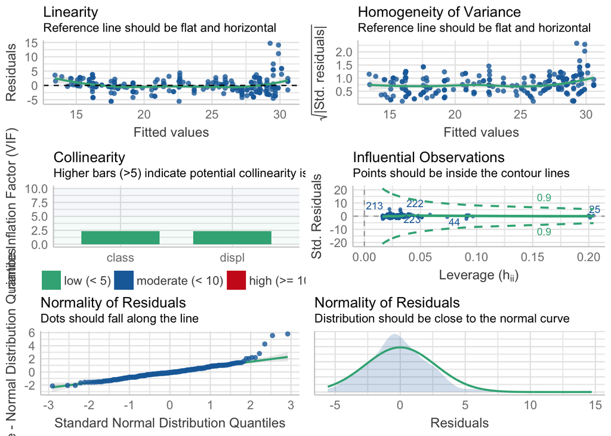

```r
check_model(model_lm)
```

- In the first plot we check the **linearity**, the reference line should be flat and horizontal. The homogeneity of variance plot give us a similar result, where the reference line should be flat and horizontal as well.
- For the **collinearity plot**: High bars indicate collinearity issues. Features with high collinearity should be removed from models that don’t include regularization. (e. g. Linear Regression).
- For the **Influential Observations plot**: We check if there is any point outside of the dashed lines., you may want to remove this point of your model to improve performance.
- **Q-Q Plot**: See how model residuals compare to a Normal Distribution. the points should follow the line. In the plot, we can see that in the end, points fall from the green line. We can investigate those points.
- **Normality Residuals**: make sure the faded blue distribution is close to the green normal curve. We see some skew towards the right.